# Factor Analyis: a case study to understand interest rates

## Interpretation

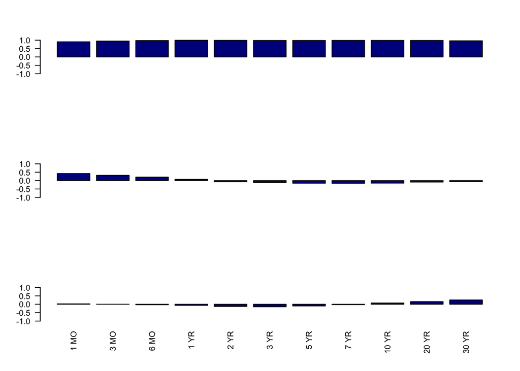

```r
par(mfrow=c(3,1))
barplot(x.f$loadings[,1], names=F, las=2, col="darkblue", ylim = c(-1, 1))
barplot(x.f$loadings[,2], names=F, las=2, col="darkblue", ylim = c(-1, 1))
barplot(x.f$loadings[,3], las=2, col="darkblue", ylim = c(-1, 1))
```

Now estimate the model with only two factors, rotation varimax (sparser representation), and Barlett estimation for scores (WLS)

```r
x.f <- factanal(X, factors = 2, rotation="varimax", scores="Bartlett", lower = 0.01)
x.f
```

```
##
## Call:
## factanal(x = X, factors = 2, scores = "Bartlett", rotation = "varimax",     lower = 0.01)
##
## Uniquenesses:
##  1 MO  3 MO  6 MO  1 YR  2 YR  3 YR  5 YR  7 YR 10 YR 20 YR 30 YR
## 0.010 0.010 0.010 0.010 0.010 0.010 0.010 0.010 0.027 0.054 0.106
##
## Loadings:
##       Factor1 Factor2
## 1 MO  0.438   0.894
## 3 MO  0.543   0.837
## 6 MO  0.633   0.771
## 1 YR  0.735   0.674
## 2 YR  0.828   0.554
## 3 YR  0.852   0.516
## 5 YR  0.871   0.487
## 7 YR  0.865   0.493
## 10 YR 0.844   0.511
## 20 YR 0.793   0.563
## 30 YR 0.746   0.581
##
##                Factor1 Factor2
## SS loadings      6.244   4.518
## Proportion Var   0.568   0.411
## Cumulative Var   0.568   0.978
##
## Test of the hypothesis that 2 factors are sufficient.
## The chi square statistic is 9308.78 on 34 degrees of freedom.
## The p-value is 0
```

```r
cbind(x.f$loadings, x.f$uniquenesses)
```

```
##         Factor1   Factor2
## 1 MO  0.4382188 0.8942375 0.01000000
## 3 MO  0.5430833 0.8373855 0.01000000
## 6 MO  0.6331857 0.7712820 0.01000000
## 1 YR  0.7347695 0.6740998 0.01000000
## 2 YR  0.8278226 0.5536344 0.01000000
## 3 YR  0.8520850 0.5155453 0.01000000
## 5 YR  0.8708204 0.4872449 0.01000000
## 7 YR  0.8654829 0.4925351 0.01000000
## 10 YR 0.8438209 0.5105014 0.02735464
## 20 YR 0.7930311 0.5627048 0.05446492
## 30 YR 0.7458300 0.5813551 0.10576378
```

The model explains very well the comovements between different maturities

That means the different products “live” in dimension 2

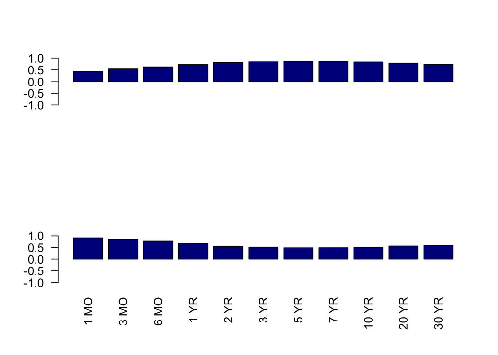

```r
par(mfrow=c(2,1))
barplot(x.f$loadings[,1], names=F, las=2, col="darkblue", ylim = c(-1, 1))
barplot(x.f$loadings[,2], las=2, col="darkblue", ylim = c(-1, 1))
```

The factors can be interpreted as two different levels: one with more weights to short-term maturities, and the other one with more weights to long-term maturities

## Scores

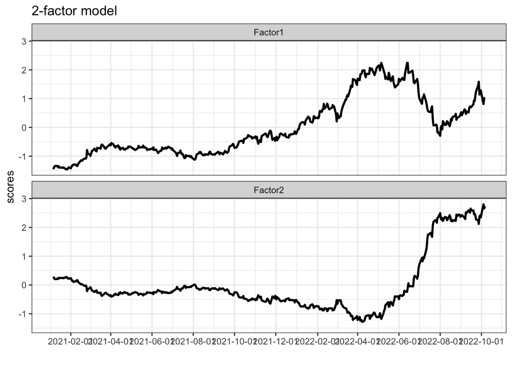

```r
factor.df = data.frame(date=date, x.f$scores) %>% gather("factor", "score", -date)

factor.df %>%
  ggplot(aes(x=date,y=score)) + geom_line(size=1) +
    scale_x_date(breaks = scales::date_breaks("2 month")) +
  theme_bw() + theme(legend.position="bottom") + scale_color_brewer(palette="Dark2") +
  facet_wrap(~factor, ncol=1) +
  labs(title="2-factor model", x="", y="scores", col="")
```

Can we forecast the interest rates for the next days?

If we are able to forecast the 2 factors, then we can forecast the yield curve using the factor model:
$$\text{rate}_t = \mu + L*f_t + a_t$$